# Análisis evolución Covid-19 Chile casos y decesos (22/04/2020)

Claudio Bustos

22/4/2020

- Reportes anteriores: https://github.com/clbustos/analisis_covid19_chile

## Análisis de series de casos

La serie de casos se hace hace partir de los 25 casos, excepto para Atacama y Aysén - donde no hay casos nuevos en los últimos días, para facilitar la comparación desde un punto de un punto de partida común.

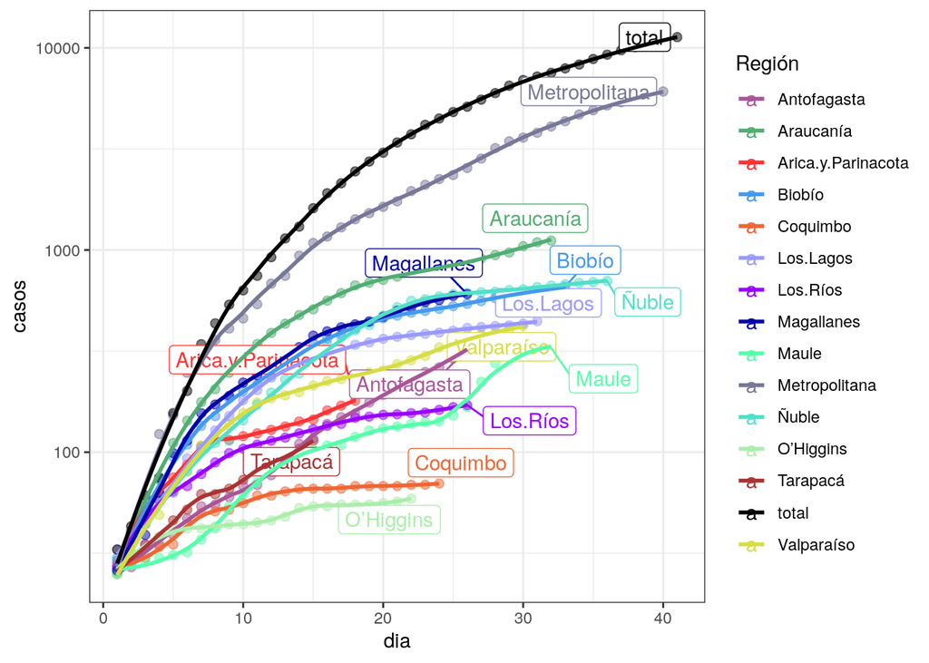

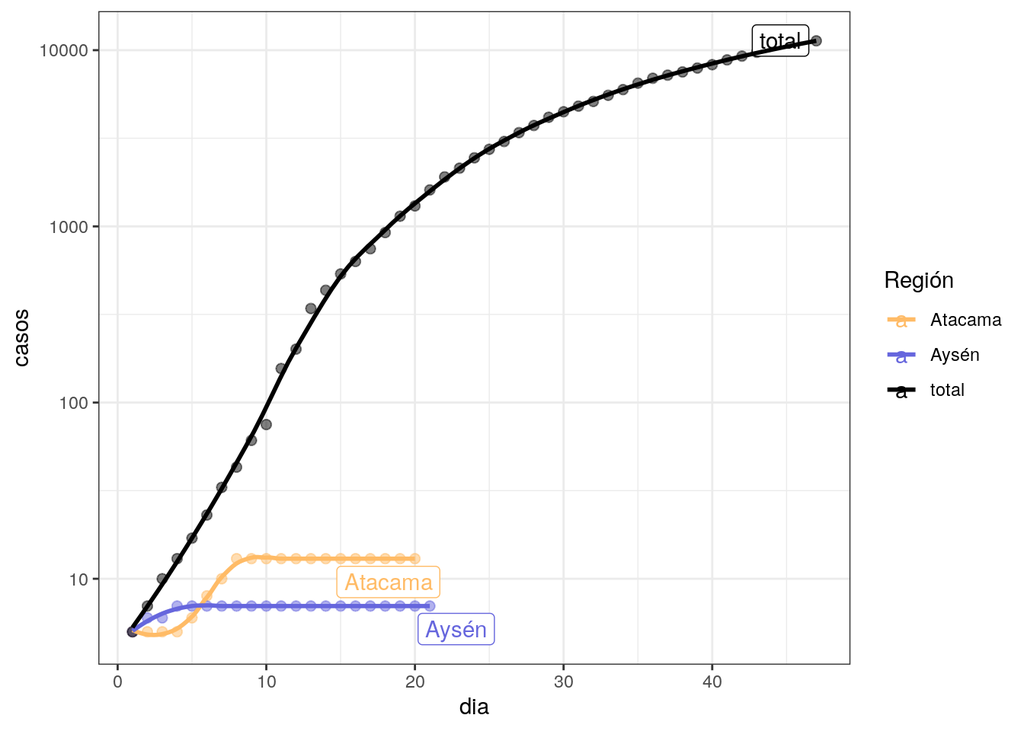

La serie por región se hace partir de los 5 primeros casos.

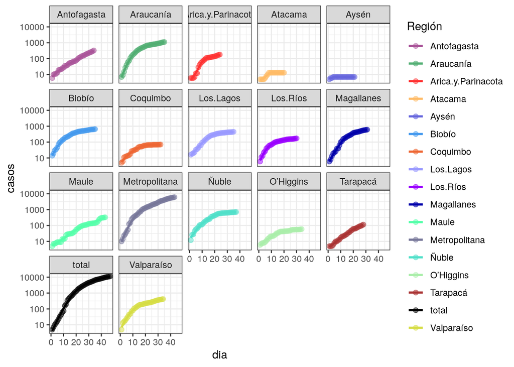

Con respecto a la serie de casos totales de día vs el anterior, se mantienen constante una tasa de incremento diario de 10% para casi todo el Norte Grande: Arica y Parinacota, Tarapacá y Antofagasta.

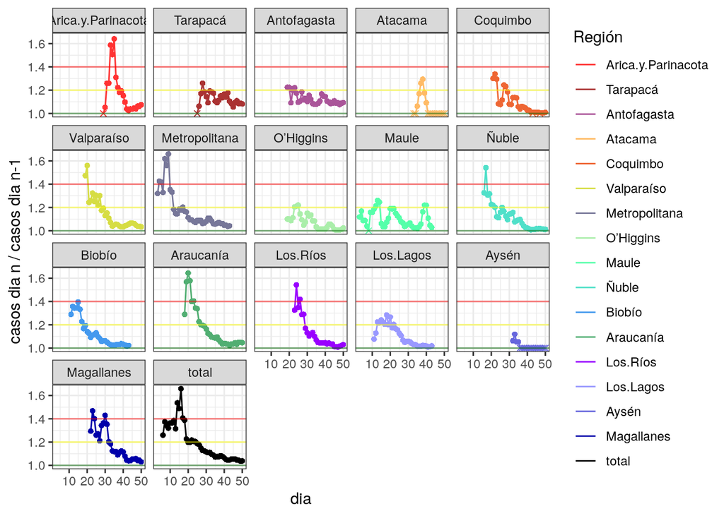

En la serie de casos nuevos diarios vs los del día anterior, con ventana de 7 días, se puede apreciar un incremento en Valparaíso, Araucanía, Los Ríos y Los Lagos. En la serie total, se puede ver que aproximadamente hace 10 días está estabilizada, lo que aparece como un crecimiento lineal.

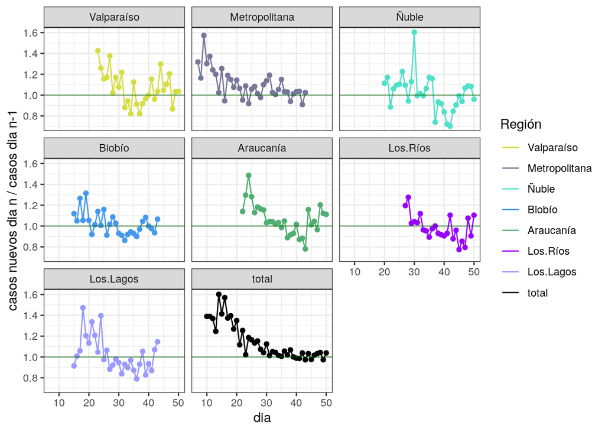

En el caso de Maule, se puede observar que en los últimos dos días se ha desacelerado la tendencia a la aceleración de los 5 días anteriores.

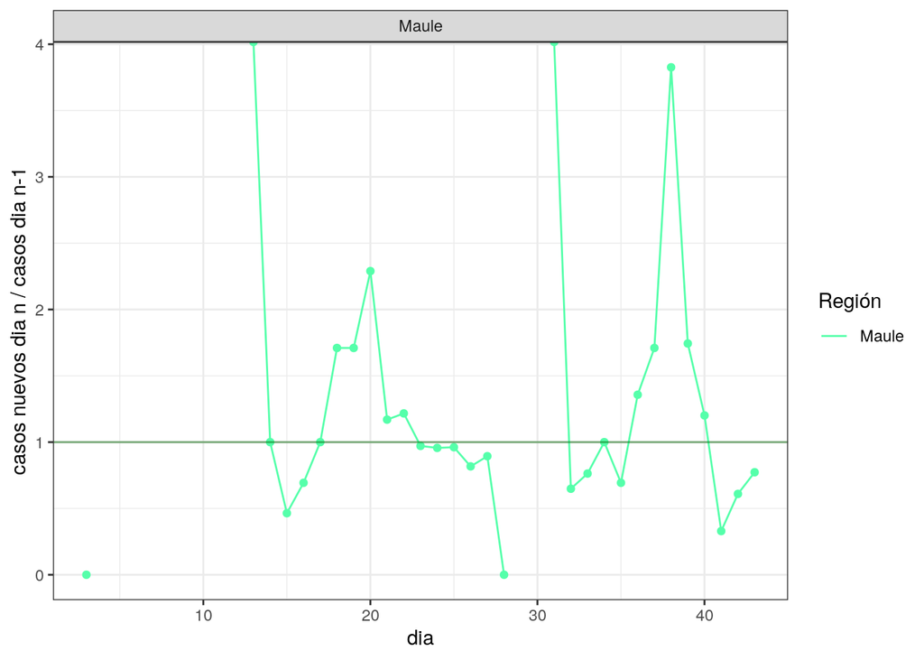

## Predicción

### Predicción para serie total

Recordemos que la regresión exponencial se eliminó, porque ya no calza con la serie total. El informe de la semana pasada mostró una subestimación constante de los modelos AR(1) + AR(4), y sobreestimación (lo que sabíamos), del modelo ARIMA. . Este último modelo se eliminará, ya que si bien los intervalos de confianza se cumplen, siempre sobreestima. A partir del análisis del resultado del algoritmo de la última semana, para la predicción total se recorta la serie a partir de lo 50 casos.

- tendencia sobre casos nuevos + AR(1) y sobre AR(4): Se modela la tendencia de los casos nuevos usando regresión exponencial, con regresión cuadradática, más la relación que existe entre mediciones contiguas. Se prueban dos modelos, uno que considera la relación solo entre cada tiempo y el anterior, AR(1), y un modelo más a largo plazo, que considera periodos de 4 días consecutivos, AR(4) . El error estándar aumenta a lo largo del tiempo, tanto por el error al calcular la tendencia, como por el componente autorregresivo. El valor medio obtenido es bastante sensible a los cambios en las mediciones finales.
- Modelo lineal cuadrático: Un modelo muy sencillo es modelar los casos totales con $ y= + _1 * dia + _2 * dia^2$, usando autocorrelación AR(2). Si bien en las pruebas muestra tener un intervalo de confianza malo y sobreestimar, tiende a tener menor error cuadrático.

|  | casos | li | ls |
| --- | --- | --- | --- |
| **Observado** | 11296 | NA | NA |
| **General: Cuadrático + AR(2)** | 12188 | 11916 | 12459 |
| **Casos nuevos : Tendencia + AR(1)** | 10282 | 9569 | 11664 |
| **Casos nuevos: Tendencia + AR(4)** | 10229 | 9554 | 11546 |

Podemos ver, al igual que en los días anteriores, que el modelo cuadrático es el más pesimista, pero los modelos T+AR(1) y T+AR(4) tienden a converger. En una semana deberíamos tener entre 12900 y 15200 casos.

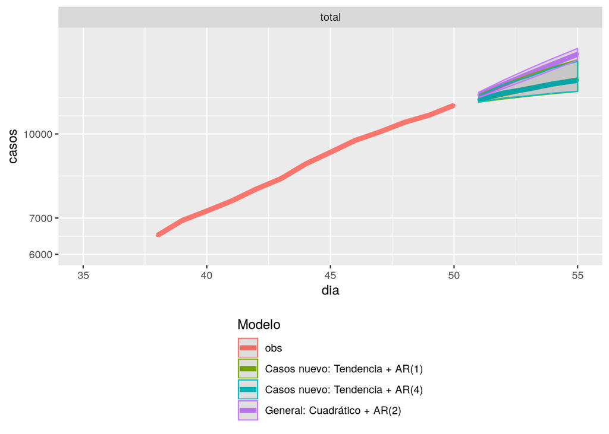

Casos nuevos: tendencia + AR(4) : total

|  | dia | casos | li | ls |
| --- | --- | --- | --- | --- |
| **40** | 51 | 11563 | 11450 | 11758 |
| **41** | 52 | 11897 | 11642 | 12339 |
| **42** | 53 | 12104 | 11755 | 12722 |
| **43** | 54 | 12367 | 11888 | 13238 |
| **44** | 55 | 12552 | 11982 | 13603 |
| **45** | 56 | 12776 | 12090 | 14064 |
| **46** | 57 | 12937 | 12168 | 14402 |

Casos nuevos: tendencia + AR(1) : total

|  | dia | casos | li | ls |
| --- | --- | --- | --- | --- |
| **40** | 51 | 11571 | 11445 | 11804 |
| **41** | 52 | 11860 | 11599 | 12348 |
| **42** | 53 | 12119 | 11736 | 12835 |
| **43** | 54 | 12358 | 11863 | 13286 |
| **44** | 55 | 12576 | 11978 | 13697 |
| **45** | 56 | 12774 | 12083 | 14070 |
| **46** | 57 | 12952 | 12178 | 14406 |

General: Modelo cuadrático : total

|  | dia | casos | li | ls |
| --- | --- | --- | --- | --- |
| **40** | 51 | 11806 | 11673 | 11940 |
| **41** | 52 | 12341 | 12122 | 12560 |
| **42** | 53 | 12892 | 12611 | 13172 |
| **43** | 54 | 13453 | 13130 | 13777 |
| **44** | 55 | 14025 | 13672 | 14378 |
| **45** | 56 | 14606 | 14232 | 14980 |
| **46** | 57 | 15196 | 14807 | 15584 |

### Predicciones para serie total usando predicción por regiones.

Otro modelo posible de análisis es usar la suma de las predicciones parciales por región. No he calculado los intervalos de confianza, porque para que sean adecuados debería considerar la covarianza entre las series de las distintas regiones.

El modelo AR(1) predice en una semana 13923, en tanto que el modelo cuadrático predice 14974.

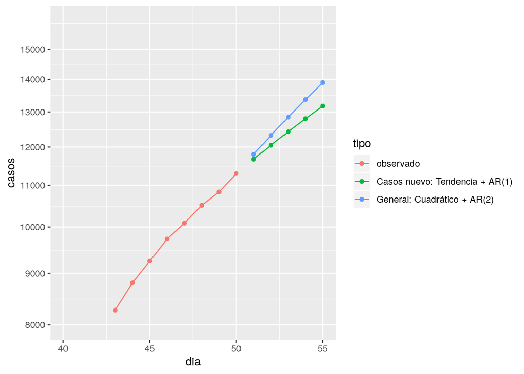

| dia | fecha | tipo | casos |
| --- | --- | --- | --- |
| 1 | 43893 | observado | 1 |
| 2 | 43894 | observado | 3 |
| 3 | 43895 | observado | 4 |
| 4 | 43896 | observado | 5 |
| 5 | 43897 | observado | 7 |
| 6 | 43898 | observado | 10 |
| 7 | 43899 | observado | 13 |
| 8 | 43900 | observado | 17 |
| 9 | 43901 | observado | 23 |
| 10 | 43902 | observado | 33 |
| 11 | 43903 | observado | 43 |
| 12 | 43904 | observado | 61 |
| 13 | 43905 | observado | 75 |
| 14 | 43906 | observado | 156 |
| 15 | 43907 | observado | 201 |
| 16 | 43908 | observado | 342 |
| 17 | 43909 | observado | 434 |
| 18 | 43910 | observado | 537 |
| 19 | 43911 | observado | 632 |
| 20 | 43912 | observado | 746 |
| 21 | 43913 | observado | 922 |
| 22 | 43914 | observado | 1142 |
| 23 | 43915 | observado | 1306 |
| 24 | 43916 | observado | 1610 |
| 25 | 43917 | observado | 1909 |
| 26 | 43918 | observado | 2139 |
| 27 | 43919 | observado | 2449 |
| 28 | 43920 | observado | 2738 |
| 29 | 43921 | observado | 3031 |
| 30 | 43922 | observado | 3404 |
| 31 | 43923 | observado | 3737 |
| 32 | 43924 | observado | 4161 |
| 33 | 43925 | observado | 4471 |
| 34 | 43926 | observado | 4815 |
| 35 | 43927 | observado | 5116 |
| 36 | 43928 | observado | 5546 |
| 37 | 43929 | observado | 5972 |
| 38 | 43930 | observado | 6501 |
| 39 | 43931 | observado | 6927 |
| 40 | 43932 | observado | 7213 |
| 41 | 43933 | observado | 7525 |
| 42 | 43934 | observado | 7917 |
| 43 | 43935 | observado | 8273 |
| 44 | 43936 | observado | 8807 |
| 45 | 43937 | observado | 9252 |
| 46 | 43938 | observado | 9730 |
| 47 | 43939 | observado | 10088 |
| 48 | 43940 | observado | 10507 |
| 49 | 43941 | observado | 10832 |
| 50 | 43942 | observado | 11296 |
| 51 | 43943 | Casos nuevo: Tendencia + AR(1) | 11672 |
| 52 | 43944 | Casos nuevo: Tendencia + AR(1) | 12051 |
| 53 | 43945 | Casos nuevo: Tendencia + AR(1) | 12427 |
| 54 | 43946 | Casos nuevo: Tendencia + AR(1) | 12802 |
| 55 | 43947 | Casos nuevo: Tendencia + AR(1) | 13176 |
| 56 | 43948 | Casos nuevo: Tendencia + AR(1) | 13549 |
| 57 | 43949 | Casos nuevo: Tendencia + AR(1) | 13923 |
| 51 | 43943 | General: Cuadrático + AR(2) | 11802 |
| 52 | 43944 | General: Cuadrático + AR(2) | 12323 |
| 53 | 43945 | General: Cuadrático + AR(2) | 12848 |
| 54 | 43946 | General: Cuadrático + AR(2) | 13373 |
| 55 | 43947 | General: Cuadrático + AR(2) | 13901 |
| 56 | 43948 | General: Cuadrático + AR(2) | 14434 |
| 57 | 43949 | General: Cuadrático + AR(2) | 14974 |

### Predicción por regiones

Eliminaremos la predicción de Atacama y Aysén, que presentan tasas estabilizadas. Se pudo reincorporar Maule ayer, que por su bruscos cambios no generaba una predicción estable para el modelo cuadrático. Recordemos que el algoritmo inicia desde 10 casos en cada Región.

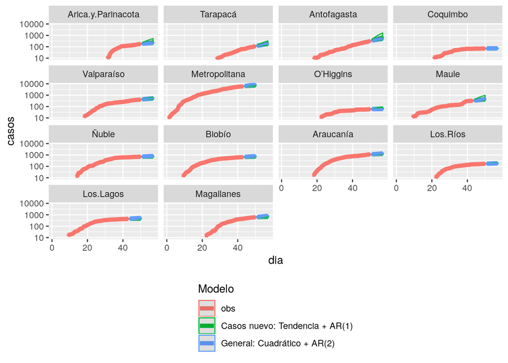

Las tablas por regiones se incluye en el Anexo I

## Ventiladores y Casos en UCI

Uso de ventiladores última semana

| fecha | total | disponibles | ocupados |
| --- | --- | --- | --- |
| 2020-04-16 | 1582 | 569 | 1013 |
| 2020-04-17 | 1604 | 579 | 1025 |
| 2020-04-18 | 1627 | 588 | 1039 |
| 2020-04-19 | 1627 | 570 | 1057 |
| 2020-04-20 | 1621 | 538 | 1083 |
| 2020-04-21 | 1614 | 521 | 1093 |
| 2020-04-22 | 1619 | 545 | 1074 |

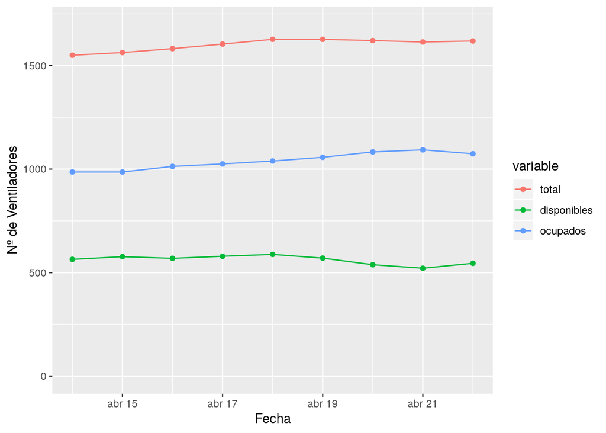

Si analizamos la serie total de pacientes en UCI para Covid-19, podemos ver que prácticamente se duplico desde inicios de mes hasta el 8 de Abril, para estabilizarse en cerca de 380 casos hasta el 20 de Abril. Hoy 22 tenemos 399 casos en UCI.

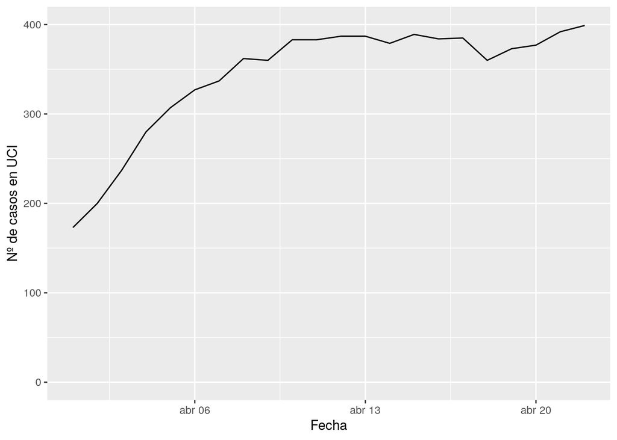

Al analizar la serie por regiones, podemos ver que en su mayoría los casos UCI se encuentran en la Región Metropolitana, que ha aumentado de forma muy fuerte su ocupación desde hace 5 días. En el resto de las regiones, podemos ver un incremento más suave, pero sostenido, en Magallanes, Los Ríos, asú como un aumento más rápido en Valparaíso. La Araucanía y Biobío han bajado sus ocupaciones durante la última semana.

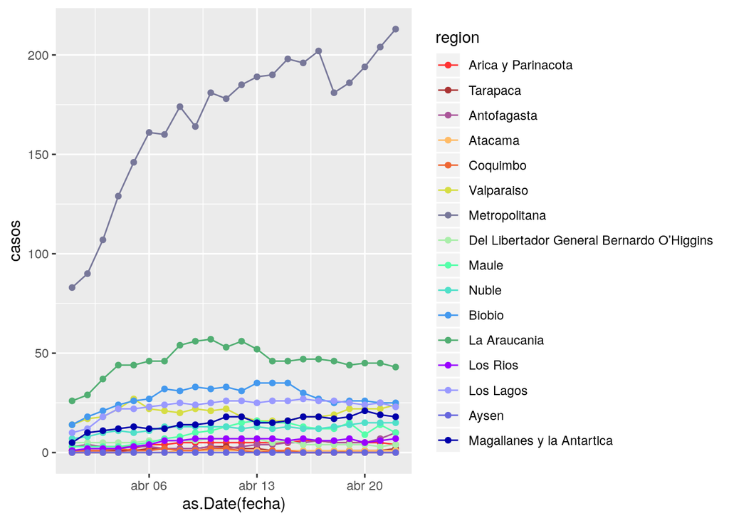

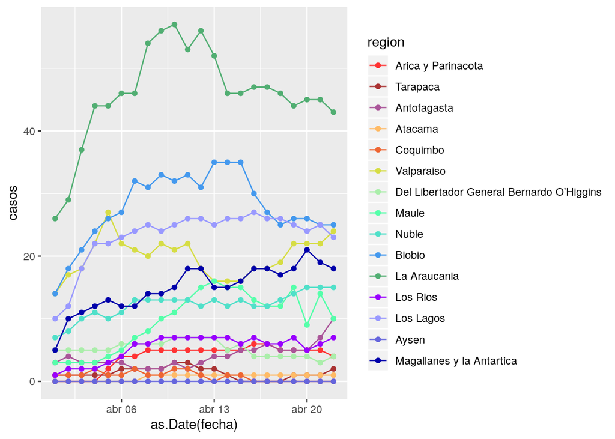

## Decesos

Si observamos la serie total de decesos, observamos una leve desaceleración de la tasa global, con un pequeño repunte en los últimos días.

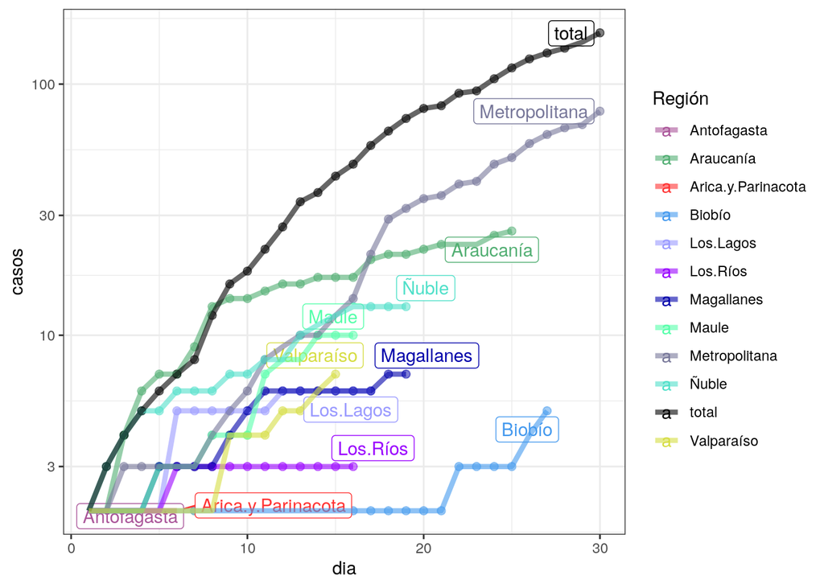

**Fuentes de información**: Principalmente, se utilizó el reporte diario del [MINSAL](https://www.minsal.cl/nuevo-coronavirus-2019-ncov/casos-confirmados-en-chile-covid-19/), usando [Wayback machine](https://archive.org/web/) para recopilar la información ya no disponible. También se ocupa la nueva serie disponible en el [Github del Ministerio de Ciencias](https://github.com/MinCiencia/Datos-COVID19).

## Anexo I: Predicciones por región

Casos nuevos: tendencia + AR(1) : Arica.y.Parinacota

|  | dia | casos | li | ls |
| --- | --- | --- | --- | --- |
| **21** | 51 | 187.6 | 181.2 | 226.9 |
| **22** | 52 | 195.2 | 182.4 | 273.7 |
| **23** | 53 | 202.8 | 183.7 | 321.5 |
| **24** | 54 | 210.7 | 185 | 370.3 |
| **25** | 55 | 218.8 | 186.2 | 420.3 |
| **26** | 56 | 227 | 187.6 | 471.6 |
| **27** | 57 | 235.5 | 188.9 | 524.3 |

Casos nuevos: tendencia + AR(1) : Tarapacá

|  | dia | casos | li | ls |
| --- | --- | --- | --- | --- |
| **24** | 51 | 121.7 | 116.3 | 140 |
| **25** | 52 | 130.1 | 118.7 | 169.2 |
| **26** | 53 | 138.7 | 121.2 | 199.1 |
| **27** | 54 | 147.6 | 123.7 | 230 |
| **28** | 55 | 156.7 | 126.4 | 261.6 |
| **29** | 56 | 166 | 129 | 293.9 |
| **30** | 57 | 175.5 | 131.8 | 326.8 |

Casos nuevos: tendencia + AR(1) : Antofagasta

|  | dia | casos | li | ls |
| --- | --- | --- | --- | --- |
| **34** | 51 | 356.5 | 333.6 | 448.2 |
| **35** | 52 | 392.5 | 342.3 | 597.8 |
| **36** | 53 | 432 | 351.8 | 762.7 |
| **37** | 54 | 476.3 | 362.4 | 947.2 |
| **38** | 55 | 525.7 | 374.2 | 1153 |
| **39** | 56 | 580.8 | 387.4 | 1382 |
| **40** | 57 | 642.3 | 402.2 | 1639 |

Casos nuevos: tendencia + AR(1) : Coquimbo

|  | dia | casos | li | ls |
| --- | --- | --- | --- | --- |
| **31** | 51 | 70.54 | 70.14 | 72.08 |
| **32** | 52 | 71.01 | 70.26 | 73.9 |
| **33** | 53 | 71.4 | 70.36 | 75.42 |
| **34** | 54 | 71.73 | 70.45 | 76.67 |
| **35** | 55 | 71.99 | 70.52 | 77.69 |
| **36** | 56 | 72.2 | 70.57 | 78.51 |
| **37** | 57 | 72.38 | 70.62 | 79.17 |

Casos nuevos: tendencia + AR(1) : Valparaíso

|  | dia | casos | li | ls |
| --- | --- | --- | --- | --- |
| **34** | 51 | 434.1 | 425.2 | 461.7 |
| **35** | 52 | 446.6 | 429.2 | 500.6 |
| **36** | 53 | 458.7 | 433.1 | 538.4 |
| **37** | 54 | 470.5 | 436.9 | 575.1 |
| **38** | 55 | 481.9 | 440.5 | 610.6 |
| **39** | 56 | 492.8 | 444.1 | 644.8 |
| **40** | 57 | 503.4 | 447.4 | 677.8 |

Casos nuevos: tendencia + AR(1) : Metropolitana

|  | dia | casos | li | ls |
| --- | --- | --- | --- | --- |
| **44** | 44 | 6280 | 6166 | 6554 |
| **45** | 45 | 6452 | 6236 | 6972 |
| **46** | 46 | 6609 | 6301 | 7354 |
| **47** | 47 | 6754 | 6360 | 7706 |
| **48** | 48 | 6886 | 6414 | 8027 |
| **49** | 49 | 7006 | 6464 | 8320 |
| **50** | 50 | 7115 | 6508 | 8585 |

Casos nuevos: tendencia + AR(1) : O’Higgins

|  | dia | casos | li | ls |
| --- | --- | --- | --- | --- |
| **30** | 51 | 60.26 | 59.39 | 63.03 |
| **31** | 52 | 61.47 | 59.77 | 66.93 |
| **32** | 53 | 62.69 | 60.15 | 70.85 |
| **33** | 54 | 63.91 | 60.53 | 74.81 |
| **34** | 55 | 65.16 | 60.91 | 78.81 |
| **35** | 56 | 66.42 | 61.31 | 82.87 |
| **36** | 57 | 67.7 | 61.7 | 87 |

Casos nuevos: tendencia + AR(1) : Maule

|  | dia | casos | li | ls |
| --- | --- | --- | --- | --- |
| **36** | 44 | 339.9 | 329.8 | 406 |
| **37** | 45 | 351.9 | 331.4 | 495.1 |
| **38** | 46 | 364.1 | 333.1 | 587.2 |
| **39** | 47 | 376.6 | 334.7 | 681.5 |
| **40** | 48 | 389.4 | 336.4 | 777.6 |
| **41** | 49 | 402.3 | 338.1 | 875.4 |
| **42** | 50 | 415.5 | 339.9 | 974.8 |

Casos nuevos: tendencia + AR(1) : Ñuble

|  | dia | casos | li | ls |
| --- | --- | --- | --- | --- |
| **38** | 51 | 707.7 | 704.1 | 722.9 |
| **39** | 52 | 711.5 | 705 | 739 |
| **40** | 53 | 714.7 | 705.8 | 752.4 |
| **41** | 54 | 717.2 | 706.4 | 763.4 |
| **42** | 55 | 719.4 | 706.9 | 772.5 |
| **43** | 56 | 721.1 | 707.3 | 779.9 |
| **44** | 57 | 722.5 | 707.6 | 785.8 |

Casos nuevos: tendencia + AR(1) : Biobío

|  | dia | casos | li | ls |
| --- | --- | --- | --- | --- |
| **36** | 44 | 668.7 | 662.6 | 682.8 |
| **37** | 45 | 677.2 | 666.2 | 702.9 |
| **38** | 46 | 684.7 | 669.4 | 720.5 |
| **39** | 47 | 691.3 | 672.2 | 736 |
| **40** | 48 | 697.1 | 674.7 | 749.6 |
| **41** | 49 | 702.1 | 676.8 | 761.5 |
| **42** | 50 | 706.5 | 678.7 | 771.8 |

Casos nuevos: tendencia + AR(1) : Araucanía

|  | dia | casos | li | ls |
| --- | --- | --- | --- | --- |
| **34** | 51 | 1135 | 1122 | 1167 |
| **35** | 52 | 1156 | 1130 | 1220 |
| **36** | 53 | 1175 | 1138 | 1270 |
| **37** | 54 | 1193 | 1145 | 1315 |
| **38** | 55 | 1209 | 1151 | 1357 |
| **39** | 56 | 1224 | 1157 | 1395 |
| **40** | 57 | 1238 | 1162 | 1429 |

Casos nuevos: tendencia + AR(1) : Los.Ríos

|  | dia | casos | li | ls |
| --- | --- | --- | --- | --- |
| **30** | 51 | 173.1 | 171.7 | 177.5 |
| **31** | 52 | 174.9 | 172.2 | 183.1 |
| **32** | 53 | 176.5 | 172.8 | 188.2 |
| **33** | 54 | 178 | 173.2 | 192.9 |
| **34** | 55 | 179.3 | 173.7 | 197 |
| **35** | 56 | 180.5 | 174.1 | 200.7 |
| **36** | 57 | 181.6 | 174.4 | 204 |

Casos nuevos: tendencia + AR(1) : Los.Lagos

|  | dia | casos | li | ls |
| --- | --- | --- | --- | --- |
| **36** | 44 | 448.1 | 445.9 | 455.5 |
| **37** | 45 | 450.4 | 446.6 | 463.3 |
| **38** | 46 | 452.1 | 447.1 | 469.4 |
| **39** | 47 | 453.5 | 447.5 | 474.2 |
| **40** | 48 | 454.6 | 447.8 | 477.9 |
| **41** | 49 | 455.4 | 448.1 | 480.7 |
| **42** | 50 | 456.1 | 448.2 | 482.8 |

Casos nuevos: tendencia + AR(1) : Magallanes

|  | dia | casos | li | ls |
| --- | --- | --- | --- | --- |
| **30** | 51 | 616.9 | 608.2 | 648.4 |
| **31** | 52 | 626.6 | 610.8 | 685 |
| **32** | 53 | 634.8 | 613 | 715.6 |
| **33** | 54 | 641.4 | 614.8 | 740.8 |
| **34** | 55 | 646.8 | 616.2 | 761.1 |
| **35** | 56 | 651.1 | 617.4 | 777.3 |
| **36** | 57 | 654.5 | 618.2 | 790 |

General: cuadrático + AR(2) : Arica.y.Parinacota

|  | dia | casos | li | ls |
| --- | --- | --- | --- | --- |
| **21** | 51 | 184.8 | 174.6 | 195.1 |
| **22** | 52 | 188.2 | 174.2 | 202.1 |
| **23** | 53 | 191.7 | 176.8 | 206.5 |
| **24** | 54 | 195.8 | 180.9 | 210.7 |
| **25** | 55 | 200.2 | 185.3 | 215.1 |
| **26** | 56 | 204.7 | 189.8 | 219.6 |
| **27** | 57 | 208.9 | 194 | 223.9 |

General: cuadrático + AR(2) : Tarapacá

|  | dia | casos | li | ls |
| --- | --- | --- | --- | --- |
| **24** | 51 | 121.8 | 117.7 | 125.8 |
| **25** | 52 | 130.2 | 126 | 134.4 |
| **26** | 53 | 139.6 | 135.4 | 143.8 |
| **27** | 54 | 149.4 | 145.2 | 153.6 |
| **28** | 55 | 159.5 | 155.3 | 163.7 |
| **29** | 56 | 169.9 | 165.7 | 174.1 |
| **30** | 57 | 180.7 | 176.4 | 184.9 |

General: cuadrático + AR(2) : Antofagasta

|  | dia | casos | li | ls |
| --- | --- | --- | --- | --- |
| **34** | 51 | 346.9 | 336.7 | 357.1 |
| **35** | 52 | 368.1 | 354.9 | 381.4 |
| **36** | 53 | 390.5 | 375.6 | 405.3 |
| **37** | 54 | 413.9 | 398.1 | 429.6 |
| **38** | 55 | 438.3 | 422 | 454.5 |
| **39** | 56 | 463.6 | 447.1 | 480.2 |
| **40** | 57 | 489.9 | 473.2 | 506.7 |

General: cuadrático + AR(2) : Coquimbo

|  | dia | casos | li | ls |
| --- | --- | --- | --- | --- |
| **31** | 51 | 70.85 | 66.24 | 75.45 |
| **32** | 52 | 71.44 | 65.09 | 77.79 |
| **33** | 53 | 71.79 | 64.66 | 78.91 |
| **34** | 54 | 71.93 | 64.48 | 79.38 |
| **35** | 55 | 71.89 | 64.3 | 79.48 |
| **36** | 56 | 71.68 | 64.04 | 79.33 |
| **37** | 57 | 71.33 | 63.66 | 79 |

General: cuadrático + AR(2) : Valparaíso

|  | dia | casos | li | ls |
| --- | --- | --- | --- | --- |
| **34** | 51 | 437.1 | 423.4 | 450.8 |
| **35** | 52 | 453.1 | 435 | 471.3 |
| **36** | 53 | 469.4 | 449.1 | 489.8 |
| **37** | 54 | 486 | 464.4 | 507.5 |
| **38** | 55 | 502.7 | 480.4 | 525 |
| **39** | 56 | 519.6 | 496.9 | 542.3 |
| **40** | 57 | 536.8 | 513.8 | 559.7 |

General: cuadrático + AR(2) : Metropolitana

|  | dia | casos | li | ls |
| --- | --- | --- | --- | --- |
| **44** | 44 | 6421 | 6326 | 6517 |
| **45** | 45 | 6766 | 6632 | 6899 |
| **46** | 46 | 7105 | 6958 | 7252 |
| **47** | 47 | 7439 | 7289 | 7589 |
| **48** | 48 | 7773 | 7622 | 7923 |
| **49** | 49 | 8110 | 7960 | 8260 |
| **50** | 50 | 8453 | 8303 | 8604 |

General: cuadrático + AR(2) : O’Higgins

|  | dia | casos | li | ls |
| --- | --- | --- | --- | --- |
| **30** | 51 | 59.57 | 56.81 | 62.32 |
| **31** | 52 | 59.58 | 55.96 | 63.2 |
| **32** | 53 | 59.55 | 55.76 | 63.34 |
| **33** | 54 | 59.6 | 55.81 | 63.4 |
| **34** | 55 | 59.72 | 55.92 | 63.52 |
| **35** | 56 | 59.81 | 56 | 63.62 |
| **36** | 57 | 59.83 | 56.02 | 63.64 |

General: cuadrático + AR(2) : Maule

|  | dia | casos | li | ls |
| --- | --- | --- | --- | --- |
| **36** | 44 | 338.2 | 322.1 | 354.2 |
| **37** | 45 | 349.4 | 321.5 | 377.2 |
| **38** | 46 | 363.5 | 328.4 | 398.6 |
| **39** | 47 | 381.1 | 342.9 | 419.3 |
| **40** | 48 | 401.9 | 363.2 | 440.6 |
| **41** | 49 | 425 | 386.3 | 463.7 |
| **42** | 50 | 449.3 | 410.1 | 488.4 |

General: cuadrático + AR(2) : Ñuble

|  | dia | casos | li | ls |
| --- | --- | --- | --- | --- |
| **38** | 51 | 718 | 688 | 748.1 |
| **39** | 52 | 735.4 | 686 | 784.7 |
| **40** | 53 | 753.3 | 690.1 | 816.5 |
| **41** | 54 | 771.2 | 698.2 | 844.2 |
| **42** | 55 | 788.8 | 708.8 | 868.9 |
| **43** | 56 | 806 | 721 | 891.1 |
| **44** | 57 | 822.8 | 734.2 | 911.5 |

General: cuadrático + AR(2) : Biobío

|  | dia | casos | li | ls |
| --- | --- | --- | --- | --- |
| **36** | 44 | 679.5 | 662.5 | 696.5 |
| **37** | 45 | 700.4 | 673.2 | 727.7 |
| **38** | 46 | 721 | 686.9 | 755.1 |
| **39** | 47 | 741.2 | 702.7 | 779.7 |
| **40** | 48 | 761.1 | 719.7 | 802.5 |
| **41** | 49 | 780.7 | 737.5 | 823.9 |
| **42** | 50 | 800.1 | 755.8 | 844.5 |

General: cuadrático + AR(2) : Araucanía

|  | dia | casos | li | ls |
| --- | --- | --- | --- | --- |
| **34** | 51 | 1146 | 1117 | 1175 |
| **35** | 52 | 1184 | 1139 | 1228 |
| **36** | 53 | 1223 | 1169 | 1276 |
| **37** | 54 | 1262 | 1204 | 1321 |
| **38** | 55 | 1302 | 1240 | 1363 |
| **39** | 56 | 1341 | 1278 | 1405 |
| **40** | 57 | 1381 | 1317 | 1445 |

General: cuadrático + AR(2) : Los.Ríos

|  | dia | casos | li | ls |
| --- | --- | --- | --- | --- |
| **30** | 51 | 172.4 | 167.4 | 177.5 |
| **31** | 52 | 173.5 | 167.4 | 179.5 |
| **32** | 53 | 174.6 | 168.5 | 180.7 |
| **33** | 54 | 175.8 | 169.8 | 181.9 |
| **34** | 55 | 176.9 | 170.8 | 183 |
| **35** | 56 | 177.7 | 171.6 | 183.8 |
| **36** | 57 | 178.2 | 172.1 | 184.3 |

General: cuadrático + AR(2) : Los.Lagos

|  | dia | casos | li | ls |
| --- | --- | --- | --- | --- |
| **36** | 44 | 458.5 | 443 | 473.9 |
| **37** | 45 | 472.1 | 444.9 | 499.2 |
| **38** | 46 | 485.5 | 449.1 | 521.9 |
| **39** | 47 | 498.8 | 455.4 | 542.1 |
| **40** | 48 | 511.8 | 463.4 | 560.1 |
| **41** | 49 | 524.5 | 472.5 | 576.5 |
| **42** | 50 | 537 | 482.4 | 591.5 |

General: cuadrático + AR(2) : Magallanes

|  | dia | casos | li | ls |
| --- | --- | --- | --- | --- |
| **30** | 51 | 631.8 | 609 | 654.6 |
| **31** | 52 | 662.6 | 629.5 | 695.7 |
| **32** | 53 | 694.3 | 655.8 | 732.7 |
| **33** | 54 | 725.8 | 684.6 | 767 |
| **34** | 55 | 757.1 | 714.6 | 799.6 |
| **35** | 56 | 788.3 | 745.1 | 831.5 |
| **36** | 57 | 819.5 | 776 | 863 |